# Make ’em Graph

Paul A. Bloom

June 27, 2018

Welcome! This tutorial will cover some basics of scatter plots, time series data, and some alternatives to bar graphs (for categorical predictors and continuous outcomes). It will also go over a few handy things along the way, such as making graphs with multiple panels, and aesthetic mapping for clearer plots.

**Note**: All examples here will be with simulated data, so that as we are making our plots we can be aware of the TRUE data generating processes and assess how well our graphs represent these.

First things first, let’s download/load ggplot!

```r
# The easiest way to get ggplot2 is to install the whole tidyverse:
install.packages("tidyverse")

# Alternatively, install just ggplot2:
install.packages("ggplot2")

# Or the the development version from GitHub:
# install.packages("devtools")
devtools::install_github("tidyverse/ggplot2")
```

```r
#load package
require(tidyverse)
```

## 0) Simulate data!

Here’s our ‘study’ – we collected several measures from 100 individuals:

- Age (years)
- Handedness (right/left)
- Vegetarian (1 = yes, 0 = no)
- Liking of ggplot (on a scale from 0-100)

Suppose we’re interested in whether age, handedness, or vegetarianism are associated with people’s feelings towards ggplot…

Let’s simulate our data!

*No need to worry about how the simulation is working right now if you’re just here for the plotting*

```r
# 100 subjects drawn from a uniform distribution between 18-56
# About equal numbers rh/lh
# Younger people a bit more likely to be vegetarian
# liking of ggplot goes down with age, a bit higher for rh and vegetarians
n <- 100
fakeStudy <- data.frame(age = runif(n, 18, 56)) %>%
  mutate(.,
         hand = rbinom(n, 1, .5),
         veg = rnorm(n, -1*age, 50),
         veg = case_when(veg >= -25 ~ 1, veg < -25 ~ 0),
         likePlot = -.75*age + 1*hand + 5*veg + rnorm(n, 80, 10))
```

## 1) Scatter Plots

It is usually helpful to make some scatter plots of raw data to visualize and understand relationships between sets of raw variables.

- We can make scatter plots of variables using the basic ggplot syntax `ggplot([data], aes(x = [x axis variable], y = [y axis variable]))` and then add the scattered points with `geom_point()`
- The `aes()` call stands for ‘aesthetic’, and it controls how variables are mapped to different axes, color, shapes, etc. Any time we want to change how different variables are mapped, we put that inside of the `aes()`
- Also remember that ggplot adds layers using the `+` sign. Each time we use it, ggplot draws a new layer of objects on top of the existing plot

Let’s use this format to plot age on the x axis and likePlot (how much people like ggplot) on the y axis here!

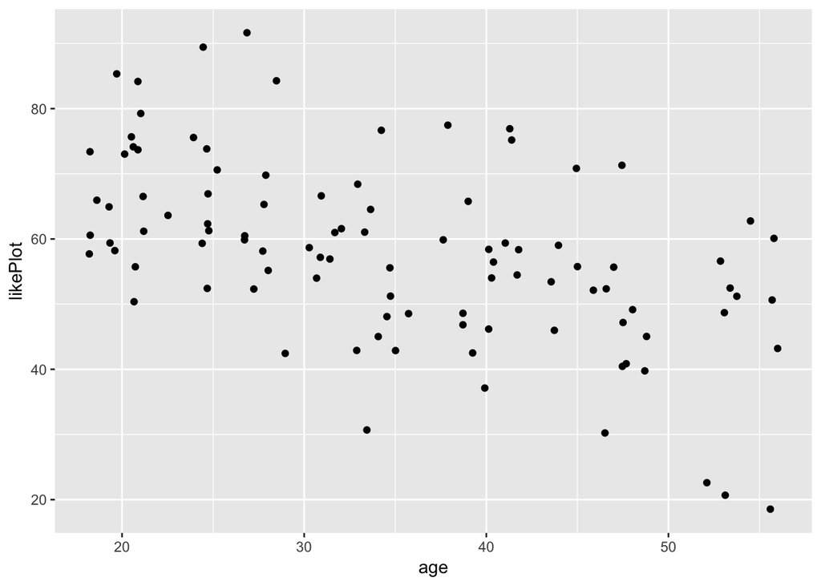

```r
ggplot(fakeStudy, aes(x = age, y = likePlot)) + geom_point()
```

Great, now let’s say we wanted to color the points based on vegetarianism.

We’ll add `color = veg` inside the `aes()` call

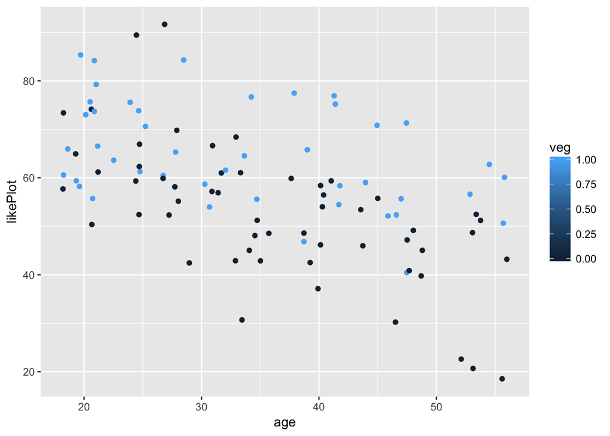

```r
ggplot(fakeStudy, aes(x = age, y = likePlot, color = veg)) + geom_point()
```

Notice how it is representing veg on a continuous scale from 0 to 1? We can fix this by recoding veg to a factor, so R doesn’t think it can take continuous values.

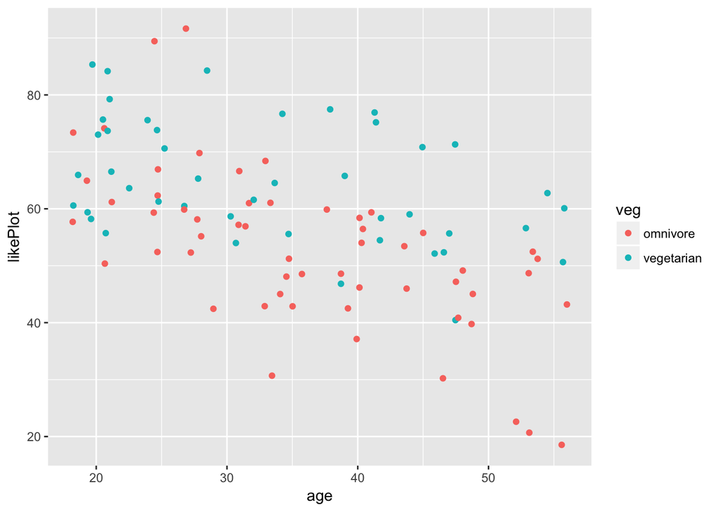

```r
fakeStudy <- mutate(fakeStudy,
                    veg = case_when(veg == 0 ~ 'omnivore', veg == 1 ~ 'vegetarian'))
ggplot(fakeStudy, aes(x = age, y = likePlot, color = veg)) + geom_point()
```

### A few aesthetics

This might be a good place to show a few ways to make the plots a bit more reader-friendly.

- We can use themes (https://ggplot2.tidyverse.org/reference/ggtheme.html) to make them look nicer. I like theme_bw() as a default
- We can use `labs(title = 'my title', x = 'x variable', y = 'y variable'` to label our plots more clearly
- Since color is also mapped using the initial `aes()` call, we can also add it to our labels the same way

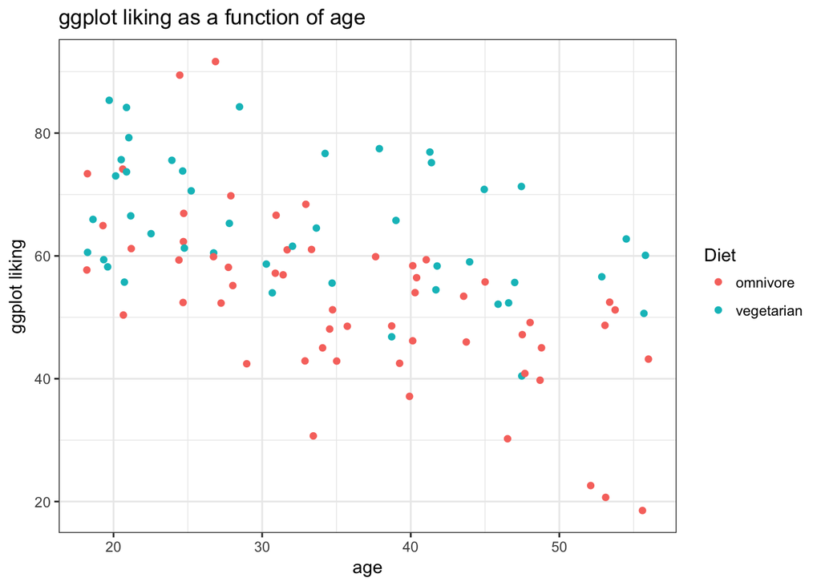

```r
ggplot(fakeStudy, aes(x = age, y = likePlot, color = veg)) +
  geom_point() +
  theme_bw() +
  labs(title = 'ggplot liking as a function of age', x = 'age', y = 'ggplot liking', color = 'Diet')
```

### Fitting lines to the data

We can also fit lines to our data with `stat_smooth()`. The default is a loess function.

- For linear models we can do `stat_smooth(method ='lm')`
- While these models are great for quick visualization, they should not substitue for more in-depth analysis of data!

Loess

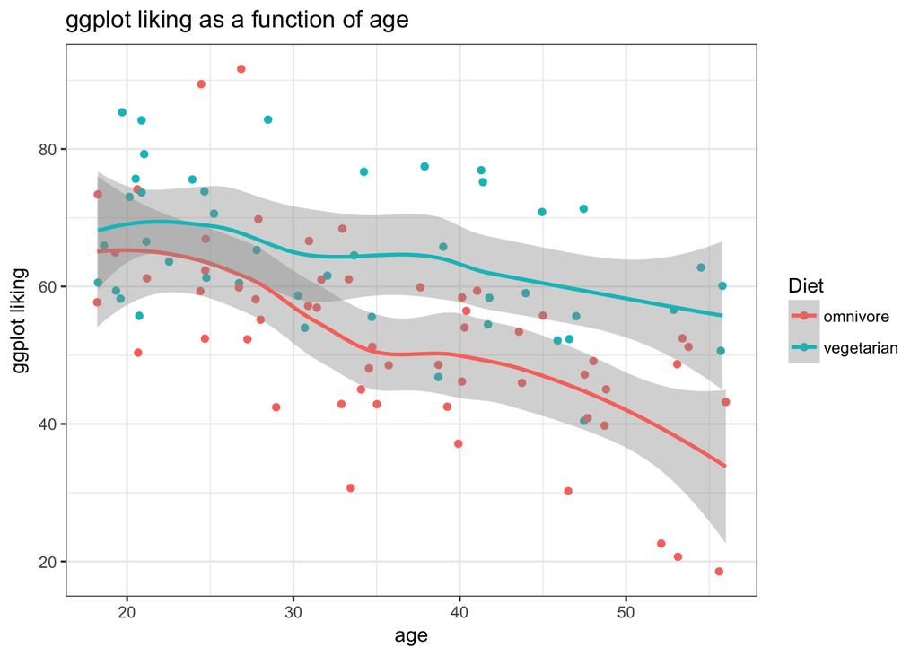

```r
ggplot(fakeStudy, aes(x = age, y = likePlot, color = veg)) +
  geom_point() +
  theme_bw() +
  labs(title = 'ggplot liking as a function of age', x = 'age', y = 'ggplot liking', color = 'Diet') +
  stat_smooth()
```

Linear

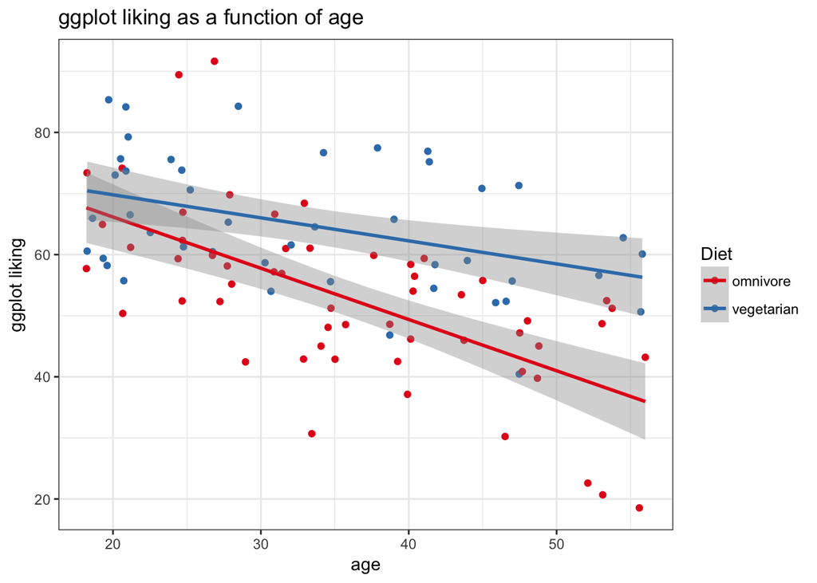

```r
ggplot(fakeStudy, aes(x = age, y = likePlot, color = veg)) +
  geom_point() +
  theme_bw() +
  labs(title = 'ggplot liking as a function of age', x = 'age', y = 'ggplot liking', color = 'Diet') +
  stat_smooth(method = 'lm') +
  scale_color_brewer(palette = 'Set1') # Using a color pallete from RColorBrewer
```

## 2) Facetting and Arranging Plots

Sometimes our comparisons are best displayed by multi-panel plots. ggplot makes this super easy

- We can call `facet_wrap('variable name')` to make a panel of the plot for each level of a categorical variable
- We can also use `facet_wrap(c('variable1', 'variable2'))` to facet by multiple variables

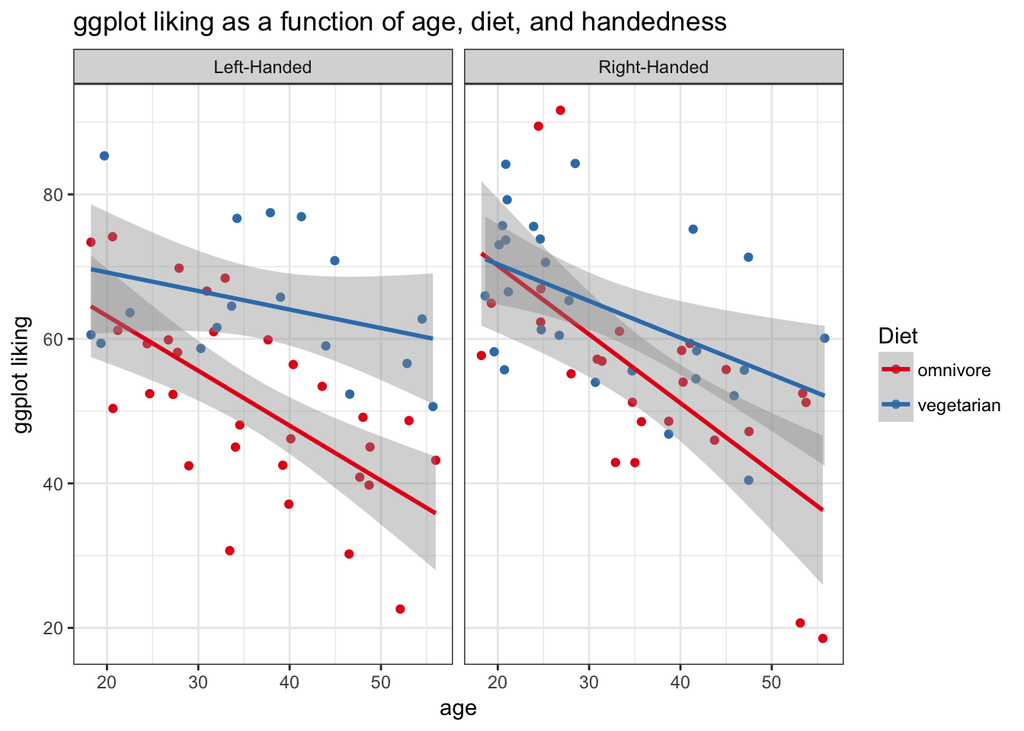

```r
fakeStudy <- mutate(fakeStudy,
                    hand = case_when(
                      hand == 0 ~ 'Left-Handed',
                      hand == 1 ~ 'Right-Handed'
                    ))

ggplot(fakeStudy, aes(x = age, y = likePlot, color = veg)) +
  geom_point() +
  theme_bw() +
  labs(title = 'ggplot liking as a function of age, diet, and handedness', x = 'age', y = 'ggplot liking', color = 'Diet') +
  stat_smooth(method = 'lm') +
  scale_color_brewer(palette = 'Set1') +
  facet_wrap('hand')
```

Or, we coluld facet by diet instead

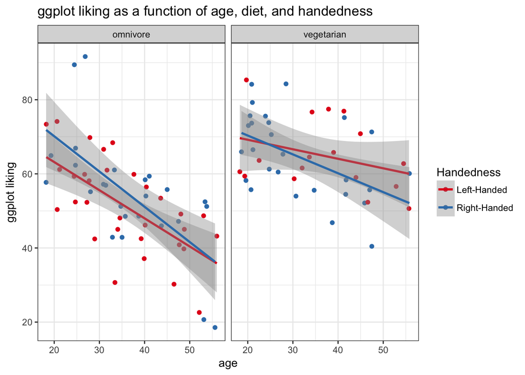

```r
ggplot(fakeStudy, aes(x = age, y = likePlot, color = hand)) +
  geom_point() +
  theme_bw() +
  labs(title = 'ggplot liking as a function of age, diet, and handedness', x = 'age', y = 'ggplot liking', color = 'Handedness') +
  stat_smooth(method = 'lm') +
  scale_color_brewer(palette = 'Set1') +
  facet_wrap('veg')
```

Keep in mind that we can’t really use `facet_wrap()` with continuous variables – ggplot will try to make a mini-panel for each observed value of your continuous measure. Probably not what we want!

### Arranging plots of different types

Using `grid.arrange()` from the gridExtra package, we can combine multiple plots into one figure. For example

```r
require(gridExtra)
```

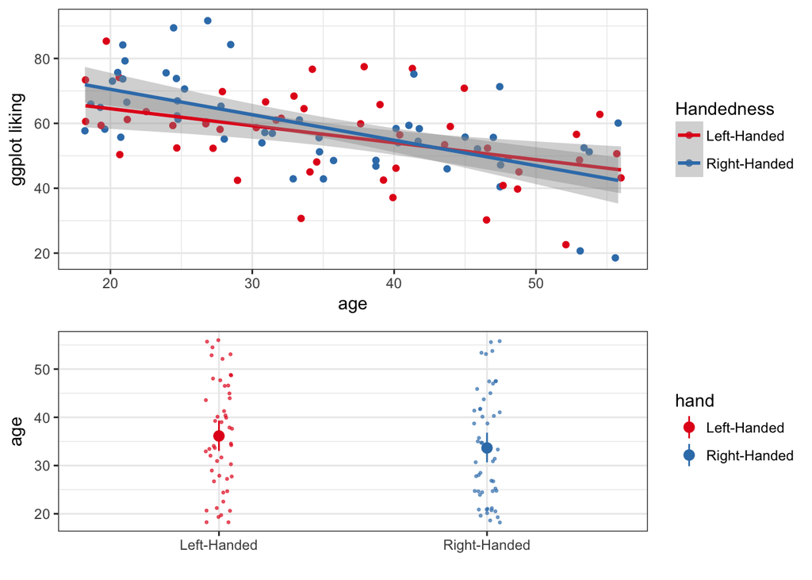

```r
plotA <- ggplot(fakeStudy, aes(x = age, y = likePlot, color = hand)) +
  geom_point() +
  theme_bw() +
  labs(x = 'age', y = 'ggplot liking', color = 'Handedness') +
  stat_smooth(method = 'lm') +
  scale_color_brewer(palette = 'Set1')


plotB <- ggplot(fakeStudy, aes(x = hand, y = age, color = hand)) +
  geom_jitter(width = .05, size = .5, alpha = .6) +
  theme_bw() +
  scale_color_brewer(palette = 'Set1') +
  stat_summary(fun.data = 'mean_cl_boot') +
  labs(x = "")

grid.arrange(plotA, plotB, ncol = 1, heights = c(5,4))
```

Or we could arrange it a little differently

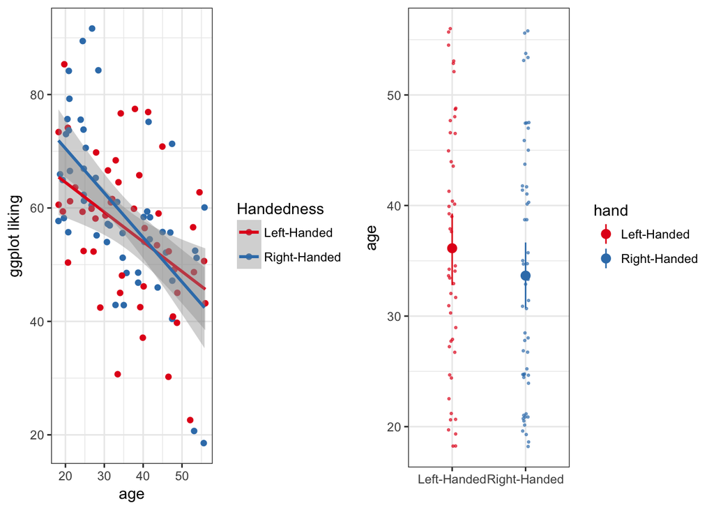

```r
plotC <- grid.arrange(plotA, plotB, ncol = 2)
```

It is also possible to save these arranged plots, just like any other ggplot object

```
ggsave(plotC, file = 'super_cool_plot.png', height = 5, width = 9)
```

## 3) Bar Graph Alternatives

Many people use bar graphs to display data, but in some situations they can hide a lot of important information. For example:

- In many settings bar graphs just display a mean and some measure of uncertainty (standard error or confidence interval) while they don’t really show the full distribution of the data. This can lead us to overemphasize the mean as a a descriptor of the data, rather than a wholistic view of the distribution.
- Bar graphs (without the raw data overplotted) don’t always convey information about sample size

However, there are some really useful alternative methods for displaying continuous outcomes as a function of categorical predictors! Here, let’s look at ggplot liking as a function of vegetarianism.

First just the points:

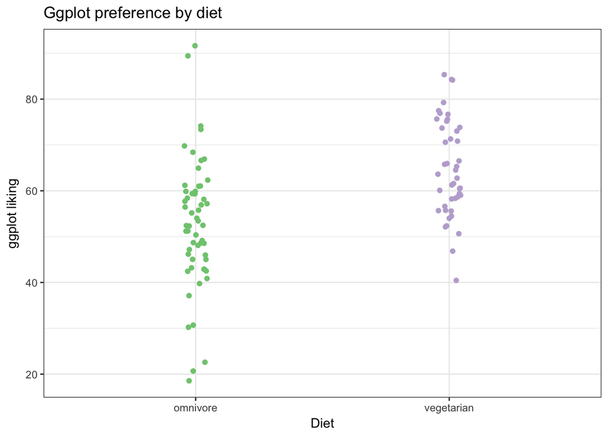

```r
# We can use source() like this to grab the fuction for geom_flat_violin() from github.
source("https://gist.githubusercontent.com/benmarwick/2a1bb0133ff568cbe28d/raw/fb53bd97121f7f9ce947837ef1a4c65a73bffb3f/geom_flat_violin.R")
ggplot(fakeStudy, aes(x = veg, y = likePlot, color = veg)) +
  geom_jitter(width = .05, height = 0) +
  theme_bw() +
  scale_color_brewer(palette = 'Accent') +
  labs(x = 'Diet', y = 'ggplot liking', title ='Ggplot preference by diet') +
  theme(legend.position = 'none') # we can make the legend go away
```

Now, we can add a ‘flat violin’ plot to help us visualize the distributions in the data. This is especially helpful when we have a lot of points, so it isn’t so clear just from looking at the raw dots.

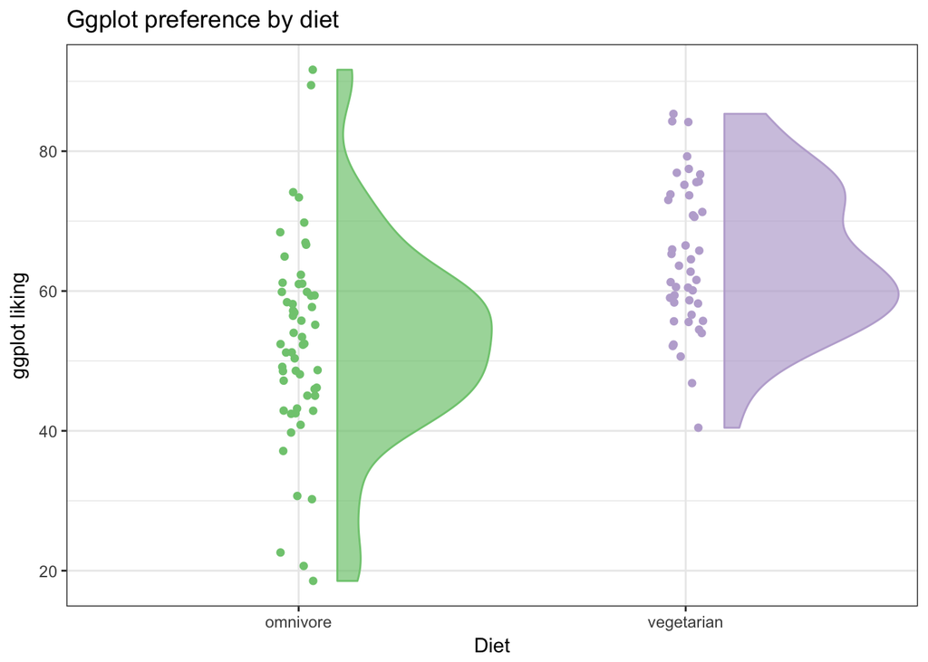

```r
# We can use source() like this to grab the fuction for geom_flat_violin() from github.
source("https://gist.githubusercontent.com/benmarwick/2a1bb0133ff568cbe28d/raw/fb53bd97121f7f9ce947837ef1a4c65a73bffb3f/geom_flat_violin.R")
ggplot(fakeStudy, aes(x = veg, y = likePlot, color = veg)) +
  geom_jitter(width = .05, height = 0) +
  theme_bw() +
  geom_flat_violin(aes(fill = veg),
                   position = position_nudge(x = .1, y = 0), alpha = .7) + # position_nudge pushes the flat violin over a bit
  scale_color_brewer(palette = 'Accent') +
  scale_fill_brewer(palette = 'Accent') +
  labs(x = 'Diet', y = 'ggplot liking', title ='Ggplot preference by diet') +
  theme(legend.position = 'none')
```

Then we can also add a summary point for the mean (or it could just as easily be the median)

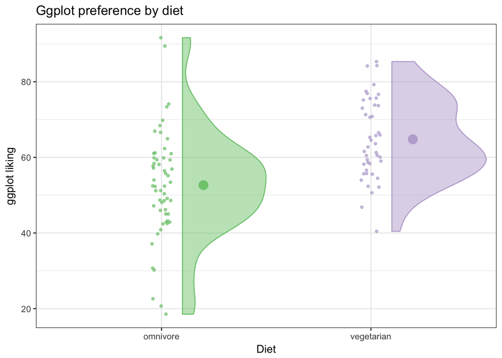

```r
ggplot(fakeStudy, aes(x = veg, y = likePlot, color = veg)) +
  geom_jitter(width = .05, height = 0, size = 1, alpha = .7) +
  theme_bw() +
  geom_flat_violin(aes(fill = veg),
                   position = position_nudge(x = .1, y = 0), alpha = .5) + # position_nudge pushes the flat violin over a bit
  scale_color_brewer(palette = 'Accent') +
  scale_fill_brewer(palette = 'Accent') +
  labs(x = 'Diet', y = 'ggplot liking', title ='Ggplot preference by diet') +
  theme(legend.position = 'none') +
  stat_summary(fun.y = mean, geom = 'point', size = 4, position = position_nudge(x =.2))
```

We can also use ggplot’s handy `stat_summary(fun.data = 'mean_cl_boot')` to calculate bootstrapped confidence intervals about the means (using Hmisc package)

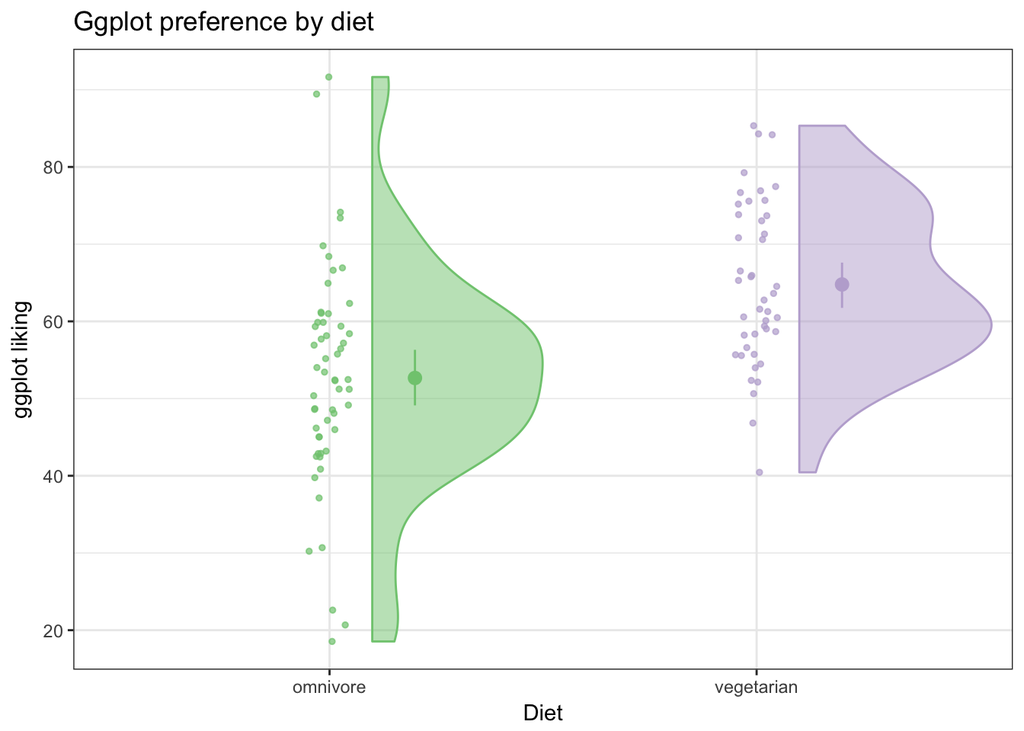

```r
ggplot(fakeStudy, aes(x = veg, y = likePlot, color = veg)) +
  geom_jitter(width = .05, height = 0, size = 1, alpha = .7) +
  theme_bw() +
  geom_flat_violin(aes(fill = veg),
                   position = position_nudge(x = .1, y = 0), alpha = .5) + # position_nudge pushes the flat violin over a bit
  scale_color_brewer(palette = 'Accent') +
  scale_fill_brewer(palette = 'Accent') +
  labs(x = 'Diet', y = 'ggplot liking', title ='Ggplot preference by diet') +
  theme(legend.position = 'none') +
  stat_summary(fun.data = 'mean_cl_boot', position = position_nudge(x =.2))
```

This is a really informative plot! We have all the information a bar graph would show, and way more! Soon, we’ll get into methods for making your own custom error bars.

## 4) Basic Time Series Plot

Lets make up some very simple data on the prices of two different items from 1978-2017

```r
years <- 1978:2017
item1<- rnorm(40,100,5)
item2 <- 1:40 + rnorm(40,100,5)


# Helpful to put it in long form using gather
timeFrame <- data.frame(years, item1, item2) %>%
  tidyr::gather(., key = 'item', value = 'price', c(item1, item2)) %>%
  mutate(se = runif(nrow(.), 1,5))
```

We can plot the time series using `geom_point()` and connect the times using `geom_line()`, coloring by item

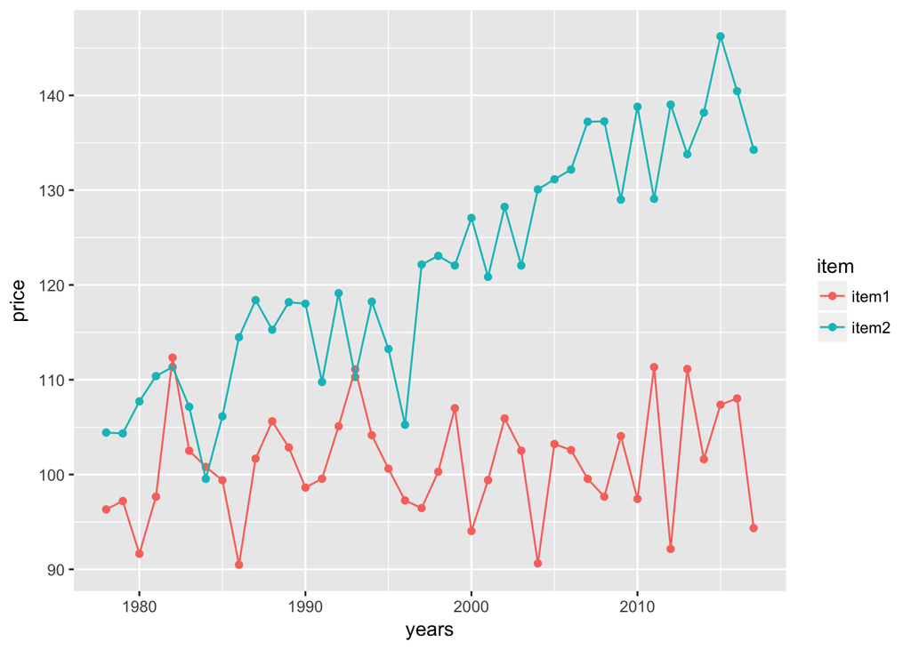

```r
ggplot(timeFrame, aes(x = years, y = price, color = item)) +
  geom_point() +
  geom_line()
```

Now, let’s get some representation of our uncertainty into the plot! Notice that there is an included ‘se’ column for the standard error of each observation. Let’s plot error bars of +/- 1 standard error above and below each point.

- We can specificy the range of the errorbars with the `ymin` and `ymax` arguments
- It can also look nice to set width to 0

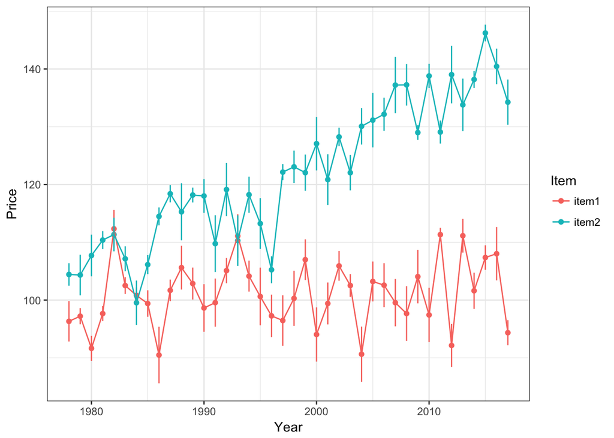

```r
ggplot(timeFrame, aes(x = years, y = price, color = item)) +
  geom_point() +
  geom_line() +
  geom_errorbar(aes(ymin = price - se, ymax = price + se), width = 0) +
  theme_bw() +
  labs(x = 'Year', y = 'Price', color = 'Item')
```

Alternatively, we can use shading to express our uncertainty more continuously. This time, lets shade the error within **2 standard errors** of each measured point

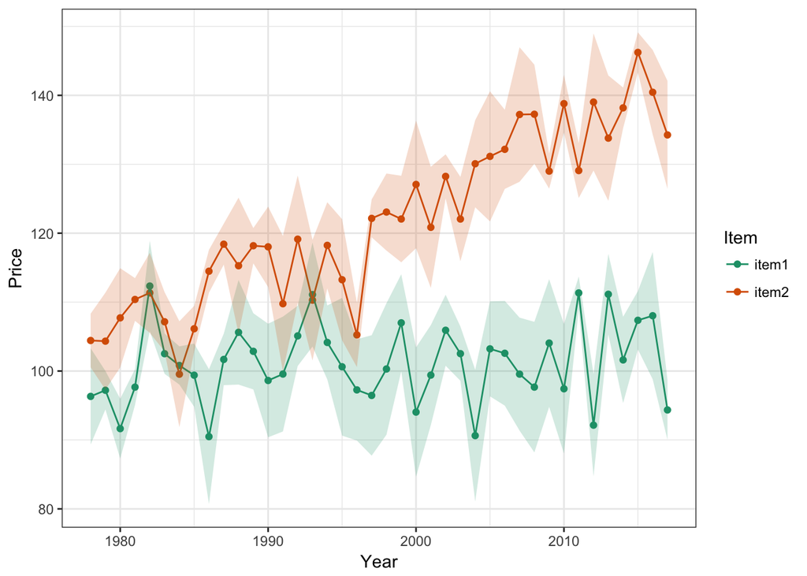

```r
ggplot(timeFrame, aes(x = years, y = price)) +
  geom_point(aes(color = item)) +
  geom_line(aes(color = item)) +
  geom_ribbon(aes(ymin = price - 2*se, ymax = price + 2*se, fill = item),
              alpha = .2, show.legend = F) +
  theme_bw() +
  labs(x = 'Year', y = 'Price', color = 'Item') +
  scale_color_brewer(palette = 'Dark2') +
  scale_fill_brewer(palette = 'Dark2')
```

Notice we’ve had to reformat a few calls here to adjust the aesthetic mapping…this happens sometimes when we want certain mappings to apply to ONLY certain parts of the plot. When we put the `aes()` call inside a `geom()` call, the mapping applies only to that geometrical object.

*Remember! It’s very important to always display the predictive uncertainty along with the estimates or mean predicted by your model. Otherwise, we don’t have any idea of how confident the model’s predictions are.*